# 第一次作业-探索武汉二手房市场

赵 炜

2024-11-03

# 1 主要发现

# 2 数据介绍

本报告**链家**数据获取方式如下：

报告人在2023年9月12日获取了[链家武汉二手房网站](https://wh.lianjia.com/ershoufang/)数据。

- 链家二手房网站默认显示100页，每页30套房产，因此本数据包括3000套房产信息；
- 数据包括了页面可见部分的文本信息，具体字段及说明见作业说明。

**说明：**数据仅用于教学；由于不清楚链家数据的展示规则，因此数据可能并不是武汉二手房市场的随机抽样，结论很可能有很大的偏差，甚至可能是错误的。

[output not shown]

# 3 数据概览

各变量的简短信息：

```
#> Rows: 3,000
#> Columns: 18
#> $ property_name     <chr> "南湖名都A区", "万科紫悦湾", "东立国际", "新都汇", "…
#> $ property_region   <chr> "南湖沃尔玛", "光谷东", "二七", "光谷广场", "团结大…
#> $ price_ttl         <dbl> 237.0, 127.0, 75.0, 188.0, 182.0, 122.0, 99.0, 193.8…
#> $ price_sqm         <dbl> 18709, 14613, 15968, 15702, 17509, 10376, 12346, 163…
#> $ bedrooms          <dbl> 3, 3, 1, 3, 3, 3, 2, 3, 4, 3, 5, 3, 4, 3, 3, 2, 3, 4…
#> $ livingrooms       <dbl> 1, 2, 1, 2, 2, 2, 1, 2, 1, 2, 2, 2, 2, 1, 2, 2, 2, 2…
#> $ building_area     <dbl> 126.68, 86.91, 46.97, 119.73, 103.95, 117.59, 80.19,…
#> $ directions1       <chr> "南", "南", "南", "北", "东南", "南", "南", "南", "…
#> $ directions2       <chr> "北", NA, NA, "东", NA, "北", NA, "北", "北", "北", …
#> $ decoration        <chr> "精装", "精装", "简装", "精装", "简装", "精装", "简…
#> $ property_t_height <dbl> 17, 28, 18, 32, 34, 34, 7, 34, 5, 7, 25, 32, 8, 31, …
#> $ property_height   <chr> "中", "中", "低", "高", "中", "低", "低", "中", "低"…
#> $ property_style    <chr> "塔楼", "板楼", "塔楼", "塔楼", "板塔结合", "板楼", …
#> $ followers         <dbl> 3, 1, 3, 2, 3, 1, 0, 0, 2, 0, 0, 0, 10, 0, 0, 1, 0, …
#> $ near_subway       <chr> "近地铁", NA, "近地铁", "近地铁", NA, NA, "近地铁", …
#> $ if_2y             <chr> NA, "房本满两年", NA, "房本满两年", "房本满两年", "…
#> $ has_key           <chr> "随时看房", "随时看房", "随时看房", "随时看房", "随…
#> $ vr                <chr> NA, "VR看装修", NA, NA, "VR看装修", NA, "VR看装修", …
```

各变量的简短统计：

```
#>  property_name      property_region      price_ttl        price_sqm
#>  Length:3000        Length:3000        Min.   :  10.6   Min.   : 1771
#>  Class :character   Class :character   1st Qu.:  95.0   1st Qu.:10799
#>  Mode  :character   Mode  :character   Median : 137.0   Median :14404
#>                                        Mean   : 155.9   Mean   :15148
#>                                        3rd Qu.: 188.0   3rd Qu.:18211
#>                                        Max.   :1380.0   Max.   :44656
#>     bedrooms      livingrooms    building_area    directions1
#>  Min.   :1.000   Min.   :0.000   Min.   : 22.77   Length:3000
#>  1st Qu.:2.000   1st Qu.:1.000   1st Qu.: 84.92   Class :character
#>  Median :3.000   Median :2.000   Median : 95.55   Mode  :character
#>  Mean   :2.695   Mean   :1.709   Mean   :100.87
#>  3rd Qu.:3.000   3rd Qu.:2.000   3rd Qu.:117.68
#>  Max.   :7.000   Max.   :4.000   Max.   :588.66
#>  directions2         decoration        property_t_height property_height
#>  Length:3000        Length:3000        Min.   : 2.00     Length:3000
#>  Class :character   Class :character   1st Qu.:11.00     Class :character
#>  Mode  :character   Mode  :character   Median :27.00     Mode  :character
#>                                        Mean   :24.22
#>                                        3rd Qu.:33.00
#>                                        Max.   :62.00
#>  property_style       followers       near_subway           if_2y
#>  Length:3000        Min.   :  0.000   Length:3000        Length:3000
#>  Class :character   1st Qu.:  1.000   Class :character   Class :character
#>  Mode  :character   Median :  3.000   Mode  :character   Mode  :character
#>                     Mean   :  6.614
#>                     3rd Qu.:  6.000
#>                     Max.   :262.000
#>    has_key               vr
#>  Length:3000        Length:3000
#>  Class :character   Class :character
#>  Mode  :character   Mode  :character
#>
#>
#>
```

# 4 探索性分析

## 4.1 房子总价的数值描述与图形

房子总价统计指标：

```
#>    Min. 1st Qu.  Median    Mean 3rd Qu.    Max.
#>    10.6    95.0   137.0   155.9   188.0  1380.0
```

使用IQR的方法，剔除极值后，房价的分布情况如下图所示：

房子总价分布图：

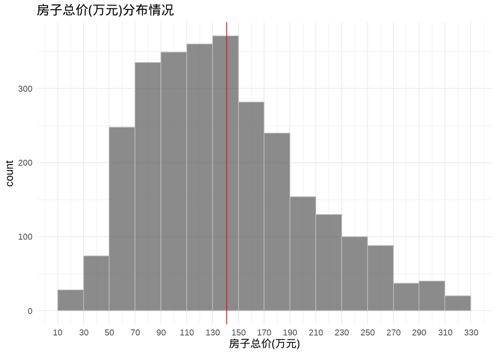

剔除异常值后发现：

- 发现1： 房子总价的平均值在140万元，在70万元到170万元之间的房子最多；
- 发现2： 房子总价的分布呈现右偏，长尾；

## 4.2 房价的数值描述与图形

房价(元/平方米) 统计指标：

```
#>    Min. 1st Qu.  Median    Mean 3rd Qu.    Max.
#>    1771   10564   14022   14433   17650   44656
```

可以看到房价的差异还是比较大的，下面通过直方图可以看看房价的分布情况。

房价(元/平方米)分布直方图：

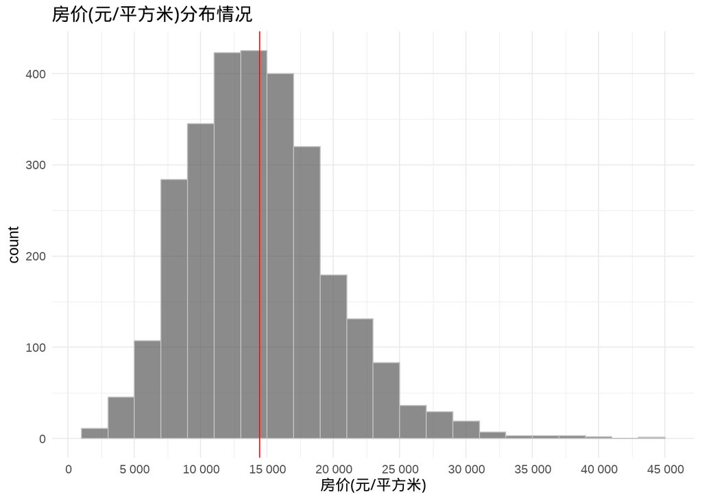

从图中可以发现：

- 1. 房价均价在1.4万元每平方米，大部分集中在1万到1.8万之间
- 2. 房价(元/平方米)的分布接近正态分布，略右偏，呈现长尾趋势，即存在相对较少的豪宅出售。

## 4.3 探索房价与区域的关系

房子位置对房价的影响很大，特别是繁华地带的，下面将分析武汉不同的区域的房价差异。

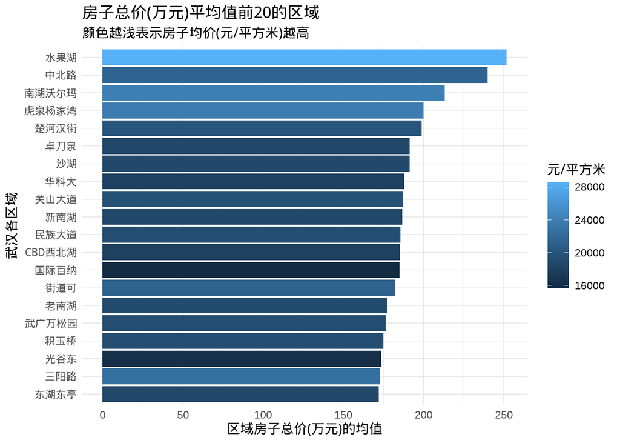

发现：

- 水果湖区域房子总价高，并且均价也高；中北路房子总价高，但是均价相对较低，说明该区域二手房的面积相对较大。
- `街道可`(口)和三阳路的两个区域的房子均价要相对较高，相同总价情况下，房子的建筑面积可能要小一些

## 4.4 房子类型与房价的关系

房屋的结构（板楼、塔楼）与是否精装修势必会影响到房价，下面分析一下这两个因素与房价的关系。

房屋结构与房价关系：

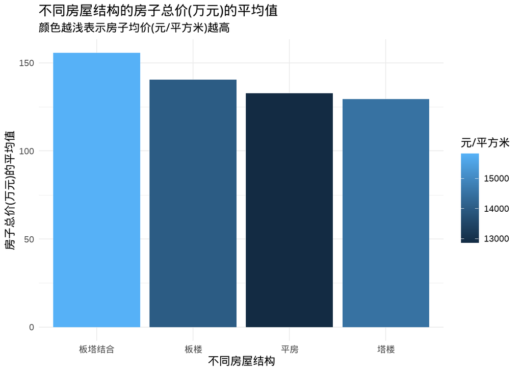

下面，进一步探索房子总价最高的前是个区域的不同房屋结构的在价格上的差异：

前十个地区为：水果湖, 中北路, 南湖沃尔玛, 虎泉杨家湾, 楚河汉街, 卓刀泉, 沙湖, 华科大, 关山大道, 新南湖 。

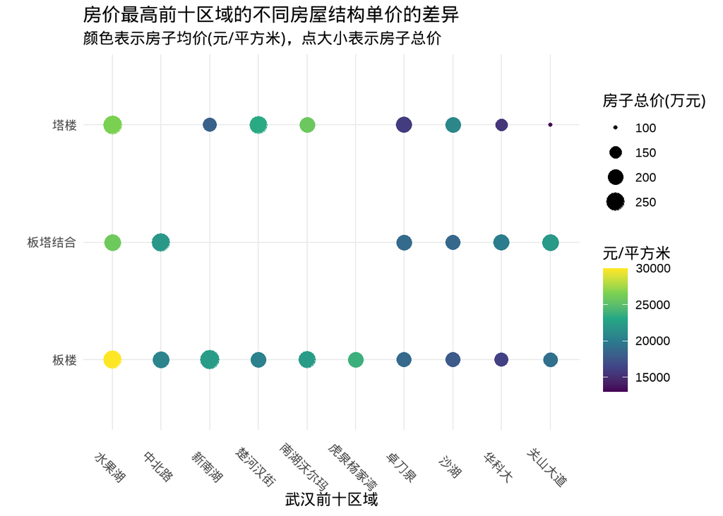

发现：

- 1. 水果湖区域，板楼的单价非常高，超过3万元每平方米；
- 2. 新南湖区域，板楼总价与单价均高于塔楼；
- 3. 板塔结合的房屋结构，在华科大与关山大道区域总价及单价均高于其他类型的房屋结构

## 4.5 交通便利度与房价的关系

一般认为离地铁近的房子，交通便利度高，房价会比没有地铁的高，下面基于这份数据探索一下。

先看一下离地铁的房子情况：

| near_subway | avg_price_ttl | avg_price_sqm | n |
| --- | --- | --- | --- |
| 近地铁 | 151.2154 | 15723.66 | 1454 |
| NA | 130.1230 | 13094.43 | 1402 |

有近一半的房子靠近地铁（去掉了房价过高数据）, 近地铁房子总价及均价都要高于非近地铁的房子。

下面结合房屋类型看一下

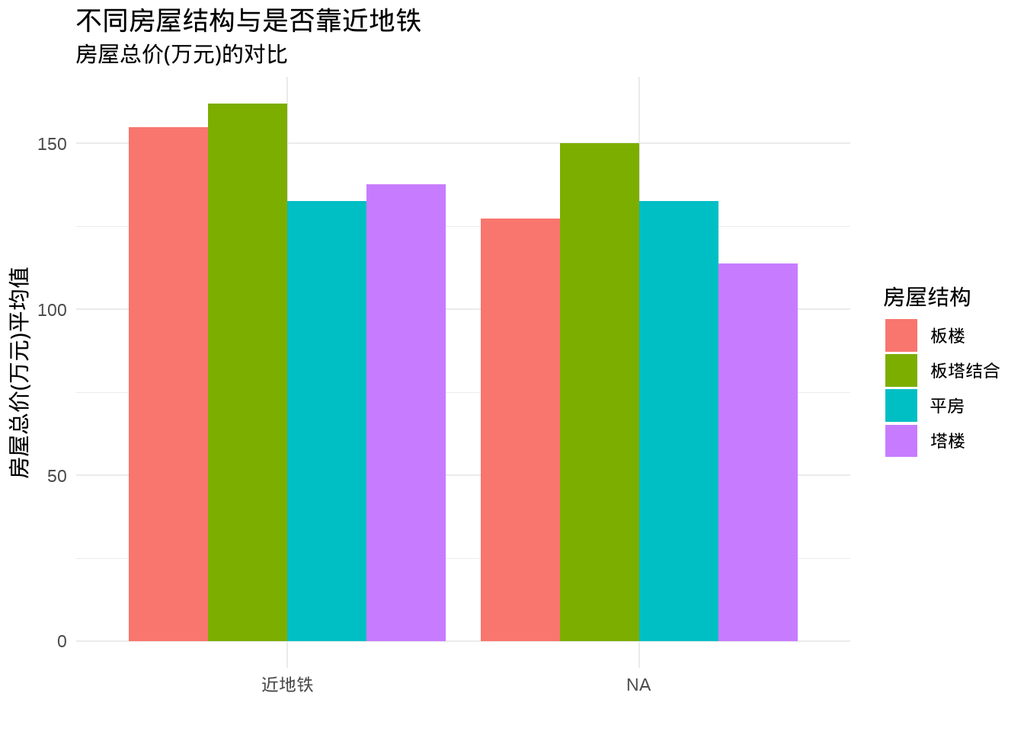

发现： 是否靠近地铁，只有对于平房没有影响，仔细看一下平房数据：

| property_name | property_region | price_ttl | price_sqm | building_area | decoration | property_t_height | property_style | near_subway |
| --- | --- | --- | --- | --- | --- | --- | --- | --- |
| 万科金色城市23地块 | 白沙洲 | 125 | 13032 | 95.92 | 精装 | 34 | 平房 | NA |
| 天汇龙城龙华苑 | 盘龙城 | 140 | 11361 | 123.23 | 精装 | 33 | 平房 | NA |
| 洪山教委宿舍 | 中南丁字桥 | 135 | 12577 | 107.34 | 简装 | 6 | 平房 | 近地铁 |
| 洪山教委宿舍 | 中南丁字桥 | 135 | 12577 | 107.34 | 简装 | 6 | 平房 | 近地铁 |
| 长安丽都 | CBD西北湖 | 128 | 14752 | 86.77 | 简装 | 18 | 平房 | 近地铁 |

发现数据可能存在填写问题，平房应该没有33高，6层高的教委宿舍是有可能，所以该类型的房子没有分析的必要性。

总体上看，靠近地铁的房子，不论是总价还是单价均高于不靠近地铁的房子。

# 5 发现总结